# FamInsureCo_OLS_Case_Study_Student_Facing_051222

## **Place your code here**

```python
faminsure_combined.columns
```

```
Index(['age', 'sex', 'bmi', 'smoker', 'region', 'medical_insurance_charges',
       'BMI_Classification', 'Age Classification', 'Age Classification_Youth',
       'Age Classification_Young Adult', 'Age Classification_Adult',
       'Age Classification_Mature Age Adult', 'Age Classification_Senior',
       'BMI_Classification_Healthy', 'BMI_Classification_Overweight',
       'BMI_Classification_Slightly Overweight',
       'BMI_Classification_Underweight', 'sex_female', 'sex_male', 'smoker_no',
       'smoker_yes', 'region_northeast', 'region_northwest',
       'region_southeast', 'region_southwest'],
      dtype='object')
```

```python
import statsmodels.api as sm


# Separate the dependent and independent variables
dependent_variable = faminsure_combined['medical_insurance_charges']
independent_variables = faminsure_combined.drop('medical_insurance_charges', axis=1)

# Convert categorical variables to dummy variables
independent_variables = pd.get_dummies(independent_variables)

# Add a constant to the independent variables
independent_variables = sm.add_constant(independent_variables)

# Fit the regression model
regression_model = sm.OLS(dependent_variable, independent_variables).fit()

# Print the regression model summary
print(regression_model.summary())
```

```
                                OLS Regression Results
=====================================================================================
Dep. Variable:     medical_insurance_charges   R-squared:                       0.755
Model:                                   OLS   Adj. R-squared:                  0.753
Method:                        Least Squares   F-statistic:                     291.7
Date:                       Tue, 21 Nov 2023   Prob (F-statistic):               0.00
Time:                               20:26:25   Log-Likelihood:                -13536.
No. Observations:                       1338   AIC:                         2.710e+04
Df Residuals:                           1323   BIC:                         2.718e+04
Df Model:                                 14
Covariance Type:                   nonrobust
==========================================================================================================
                                             coef    std err          t      P>|t|      [0.025      0.975]
----------------------------------------------------------------------------------------------------------
const                                    449.0098    406.730      1.104      0.270    -348.897    1246.916
age                                      334.3442     31.647     10.565      0.000     272.260     396.428
bmi                                      149.0475     53.702      2.775      0.006      43.698     254.397
Age Classification_Youth                 578.9517    400.526      1.445      0.149    -206.783    1364.687
Age Classification_Young Adult          1078.5906    269.265      4.006      0.000     550.357    1606.824
Age Classification_Adult                  87.5217    195.554      0.448      0.655    -296.107     471.151
Age Classification_Mature Age Adult     -438.2834    282.676     -1.550      0.121    -992.825     116.258
Age Classification_Senior               -857.7707    544.039     -1.577      0.115   -1925.044     209.503
BMI_Classification_Healthy              -239.5769    229.980     -1.042      0.298    -690.742     211.588
BMI_Classification_Overweight           1225.4996    378.701      3.236      0.001     482.579    1968.420
BMI_Classification_Slightly Overweight   -97.6059    243.560     -0.401      0.689    -575.413     380.201
BMI_Classification_Underweight          -439.3071    550.219     -0.798      0.425   -1518.704     640.090
sex_female                               253.8539    218.579      1.161      0.246    -174.946     682.653
sex_male                                 195.1559    220.480      0.885      0.376    -237.373     627.684
smoker_no                              -5747.9263    224.708    -25.580      0.000   -6188.749   -5307.104
smoker_yes                              6196.9361    231.119     26.813      0.000    5743.536    6650.336
region_northeast                         414.3376    174.093      2.380      0.017      72.809     755.866
region_northwest                         178.1227    170.526      1.045      0.296    -156.409     512.654
region_southeast                         -44.8303    191.869     -0.234      0.815    -421.230     331.570
region_southwest                         -98.6202    177.364     -0.556      0.578    -446.565     249.325
sex_female                               253.8539    218.579      1.161      0.246    -174.946     682.653
sex_male                                 195.1559    220.480      0.885      0.376    -237.373     627.684
smoker_no                              -5747.9263    224.708    -25.580      0.000   -6188.749   -5307.104
smoker_yes                              6196.9361    231.119     26.813      0.000    5743.536    6650.336
region_northeast                         414.3376    174.093      2.380      0.017      72.809     755.866
region_northwest                         178.1227    170.526      1.045      0.296    -156.409     512.654
region_southeast                         -44.8303    191.869     -0.234      0.815    -421.230     331.570
region_southwest                         -98.6202    177.364     -0.556      0.578    -446.565     249.325
BMI_Classification_Healthy              -239.5769    229.980     -1.042      0.298    -690.742     211.588
BMI_Classification_Overweight           1225.4996    378.701      3.236      0.001     482.579    1968.420
BMI_Classification_Slightly Overweight   -97.6059    243.560     -0.401      0.689    -575.413     380.201
BMI_Classification_Underweight          -439.3071    550.219     -0.798      0.425   -1518.704     640.090
Age Classification_Youth                 578.9517    400.526      1.445      0.149    -206.783    1364.687
Age Classification_Young Adult          1078.5906    269.265      4.006      0.000     550.357    1606.824
Age Classification_Adult                  87.5217    195.554      0.448      0.655    -296.107     471.151
Age Classification_Mature Age Adult     -438.2834    282.676     -1.550      0.121    -992.825     116.258
Age Classification_Senior               -857.7707    544.039     -1.577      0.115   -1925.044     209.503
==============================================================================
Omnibus:                      317.473   Durbin-Watson:                   1.177
Prob(Omnibus):                  0.000   Jarque-Bera (JB):              767.365
Skew:                           1.275   Prob(JB):                    2.34e-167
Kurtosis:                       5.695   Cond. No.                     3.53e+17
==============================================================================

Notes:
[1] Standard Errors assume that the covariance matrix of the errors is correctly specified.
[2] The smallest eigenvalue is 2.83e-29. This might indicate that there are
strong multicollinearity problems or that the design matrix is singular.
```

**What do you observe from the R Squared Value in your model? Is the model a good fit or a poor fit?**

An R-squared of 0.755 is a strong fit. This means that 75.5% of the variance in the dependent variable can be explained by the independent variables. This is a very good result, and it indicates that the model is a good predictor of the dependent variable.

### Step 16: Use OLS Regression Again

Now we've fitted a model using the `Faminsureco_Combined` Dataframe, where we haven't removed any outliers from our data. Now we know that Outliers are deviations in our dataset, greater than +- 3 standard deviations away from our population mean.

Would our model potentially score higher if we *remove* these outliers from our analysis? Let's take a look and try this out!

**i) Remove the Outliers from the `FamInsureCo_Combined` Dataframe using the Syntax we've highlighted below and store this in a new dataframe called `FamInsureCo_Combined_Dataframe_Outliers_Removed`**

```
Q1 = faminsureco_combined['medical_insurance_charges'].quantile(0.25)
Q3 = faminsureco_combined['medical_insurance_charges'].quantile(0.75)
IQR = Q3 - Q1
Upper_Limit = Q3 + 1.5 * IQR
faminsureco_combined[~(faminsureco_combined['medical_insurance_charges'] > Upper_Limit)]
```

ii) Upon completion of this, create a regression equation that models the Medical Insurance Charges (Y-Variable) against all your independent variables in the `FamInsureCo_Combined_Dataframe_Outliers_Removed` dataframe.

**Hint: Watch out for the capitalisation; Python is case sensitive so be careful when looking at your variable names!**

```python
Q1 = faminsure_combined['medical_insurance_charges'].quantile(0.25)
Q3 = faminsure_combined['medical_insurance_charges'].quantile(0.75)
IQR = Q3 - Q1
Upper_Limit = Q3 + 1.5 * IQR
FamInsureCo_Combined_Dataframe_Outliers_Removed = faminsure_combined[~(faminsure_combined['medical_insurance_charges'] > Upper_Limit)]

FamInsureCo_Combined_Dataframe_Outliers_Removed
```

|  | age | sex | bmi | smoker | region | medical_insurance_charges | BMI_Classification | Age Classification | Age Classification_Youth | Age Classification_Young Adult | ... | BMI_Classification_Slightly Overweight | BMI_Classification_Underweight | sex_female | sex_male | smoker_no | smoker_yes | region_northeast | region_northwest | region_southeast | region_southwest |
| --- | --- | --- | --- | --- | --- | --- | --- | --- | --- | --- | --- | --- | --- | --- | --- | --- | --- | --- | --- | --- | --- |
| 0 | 18 | female | 20.790 | no | southeast | 1607.51 | Healthy | Youth | 1 | 0 | ... | 0 | 0 | 1 | 0 | 1 | 0 | 0 | 0 | 1 | 0 |
| 1 | 18 | female | 24.090 | no | southeast | 2201.10 | Healthy | Youth | 1 | 0 | ... | 0 | 0 | 1 | 0 | 1 | 0 | 0 | 0 | 1 | 0 |
| 2 | 19 | female | 24.700 | no | southwest | 1737.38 | Healthy | Young Adult | 0 | 1 | ... | 0 | 0 | 1 | 0 | 1 | 0 | 0 | 0 | 0 | 1 |
| 3 | 19 | female | 24.510 | no | northwest | 2709.11 | Healthy | Young Adult | 0 | 1 | ... | 0 | 0 | 1 | 0 | 1 | 0 | 0 | 1 | 0 | 0 |
| 4 | 19 | female | 22.515 | no | northwest | 2117.34 | Healthy | Young Adult | 0 | 1 | ... | 0 | 0 | 1 | 0 | 1 | 0 | 0 | 1 | 0 | 0 |
| ... | ... | ... | ... | ... | ... | ... | ... | ... | ... | ... | ... | ... | ... | ... | ... | ... | ... | ... | ... | ... | ... |
| 1333 | 32 | female | 17.765 | yes | northwest | 32734.19 | Underweight | Adult | 0 | 0 | ... | 0 | 1 | 1 | 0 | 0 | 1 | 0 | 1 | 0 | 0 |
| 1334 | 27 | female | 17.955 | yes | northeast | 15006.58 | Underweight | Adult | 0 | 0 | ... | 0 | 1 | 1 | 0 | 0 | 1 | 1 | 0 | 0 | 0 |
| 1335 | 26 | female | 17.195 | yes | northeast | 14455.64 | Underweight | Adult | 0 | 0 | ... | 0 | 1 | 1 | 0 | 0 | 1 | 1 | 0 | 0 | 0 |
| 1336 | 39 | female | 18.300 | yes | southwest | 19023.26 | Underweight | Mature Age Adult | 0 | 0 | ... | 0 | 1 | 1 | 0 | 0 | 1 | 0 | 0 | 0 | 1 |
| 1337 | 18 | male | 17.290 | yes | northeast | 12829.46 | Underweight | Youth | 1 | 0 | ... | 0 | 1 | 0 | 1 | 0 | 1 | 1 | 0 | 0 | 0 |

1199 rows × 25 columns

```python
# Separate the dependent and independent variables
dependent_variable_2 = FamInsureCo_Combined_Dataframe_Outliers_Removed['medical_insurance_charges']
independent_variables_2 = FamInsureCo_Combined_Dataframe_Outliers_Removed.drop('medical_insurance_charges', axis=1)

# Convert categorical variables to dummy variables
independent_variables_2 = pd.get_dummies(independent_variables_2)

# Add a constant to the independent variables
independent_variables_2 = sm.add_constant(independent_variables_2)

# Fit the regression model
regression_model_2 = sm.OLS(dependent_variable_2, independent_variables_2).fit()

# Print the regression model summary
print(regression_model_2.summary())
```

```
                                OLS Regression Results
=====================================================================================
Dep. Variable:     medical_insurance_charges   R-squared:                       0.611
Model:                                   OLS   Adj. R-squared:                  0.606
Method:                        Least Squares   F-statistic:                     132.8
Date:                       Tue, 21 Nov 2023   Prob (F-statistic):          6.15e-231
Time:                               20:26:33   Log-Likelihood:                -11791.
No. Observations:                       1199   AIC:                         2.361e+04
Df Residuals:                           1184   BIC:                         2.369e+04
Df Model:                                 14
Covariance Type:                   nonrobust
==========================================================================================================
                                             coef    std err          t      P>|t|      [0.025      0.975]
----------------------------------------------------------------------------------------------------------
const                                    823.3059    330.464      2.491      0.013     174.945    1471.667
age                                      326.8242     25.465     12.834      0.000     276.862     376.786
bmi                                      -34.2002     44.566     -0.767      0.443    -121.638      53.238
Age Classification_Youth                 884.2274    316.740      2.792      0.005     262.792    1505.663
Age Classification_Young Adult          1125.3514    214.570      5.245      0.000     704.371    1546.331
Age Classification_Adult                  36.9558    156.549      0.236      0.813    -270.189     344.100
Age Classification_Mature Age Adult     -565.0908    227.467     -2.484      0.013   -1011.374    -118.808
Age Classification_Senior               -658.1379    438.632     -1.500      0.134   -1518.720     202.444
BMI_Classification_Healthy                47.3258    174.881      0.271      0.787    -295.786     390.437
BMI_Classification_Overweight            864.1055    307.364      2.811      0.005     261.067    1467.144
BMI_Classification_Slightly Overweight   447.9229    189.916      2.359      0.019      75.314     820.532
BMI_Classification_Underweight          -536.0484    418.347     -1.281      0.200   -1356.831     284.735
sex_female                               500.7423    176.576      2.836      0.005     154.306     847.178
sex_male                                 322.5636    179.041      1.802      0.072     -28.710     673.837
smoker_no                              -3265.2024    194.918    -16.752      0.000   -3647.626   -2882.779
smoker_yes                              4088.5083    199.434     20.501      0.000    3697.225    4479.792
region_northeast                         546.9593    139.257      3.928      0.000     273.741     820.178
region_northwest                         361.0895    134.632      2.682      0.007      96.946     625.233
region_southeast                          56.0789    154.344      0.363      0.716    -246.739     358.897
region_southwest                        -140.8218    143.428     -0.982      0.326    -422.224     140.580
sex_female                               500.7423    176.576      2.836      0.005     154.306     847.178
sex_male                                 322.5636    179.041      1.802      0.072     -28.710     673.837
smoker_no                              -3265.2024    194.918    -16.752      0.000   -3647.626   -2882.779
smoker_yes                              4088.5083    199.434     20.501      0.000    3697.225    4479.792
region_northeast                         546.9593    139.257      3.928      0.000     273.741     820.178
region_northwest                         361.0895    134.632      2.682      0.007      96.946     625.233
region_southeast                          56.0789    154.344      0.363      0.716    -246.739     358.897
region_southwest                        -140.8218    143.428     -0.982      0.326    -422.224     140.580
BMI_Classification_Healthy                47.3258    174.881      0.271      0.787    -295.786     390.437
BMI_Classification_Overweight            864.1055    307.364      2.811      0.005     261.067    1467.144
BMI_Classification_Slightly Overweight   447.9229    189.916      2.359      0.019      75.314     820.532
BMI_Classification_Underweight          -536.0484    418.347     -1.281      0.200   -1356.831     284.735
Age Classification_Youth                 884.2274    316.740      2.792      0.005     262.792    1505.663
Age Classification_Young Adult          1125.3514    214.570      5.245      0.000     704.371    1546.331
Age Classification_Adult                  36.9558    156.549      0.236      0.813    -270.189     344.100
Age Classification_Mature Age Adult     -565.0908    227.467     -2.484      0.013   -1011.374    -118.808
Age Classification_Senior               -658.1379    438.632     -1.500      0.134   -1518.720     202.444
==============================================================================
Omnibus:                      734.048   Durbin-Watson:                   1.859
Prob(Omnibus):                  0.000   Jarque-Bera (JB):             4967.131
Skew:                           2.934   Prob(JB):                         0.00
Kurtosis:                      11.062   Cond. No.                     1.04e+17
==============================================================================

Notes:
[1] Standard Errors assume that the covariance matrix of the errors is correctly specified.
[2] The smallest eigenvalue is 2.85e-28. This might indicate that there are
strong multicollinearity problems or that the design matrix is singular.
```

#### **Compare the Models you've created and observe the R Squared displayed for each model - which model seems better and why? Put your thoughts down below.** If you're not sure how to answer this, you should reference the resource [here](https://blog.minitab.com/en/adventures-in-statistics-2/regression-analysis-how-do-i-interpret-r-squared-and-assess-the-goodness-of-fit) for a more detailed explanation.

The first one has better R-Squared Value.

### Step 17: Analysis of Coefficients

Great job creating those regressive equations! You've reached the final two steps of this case study!

We've now identified that *one* of our regressive models has a better fit than the previous model.

Using this model, we want to **extract** the co-efficients to better understand the variables that display the largest *absolute* rate of change with respect to `medical_insurance_charges`. We'll use the co-efficients to better assess this from an *absolute* rate of change perspective. (i.e. Which variables spike the most in relation to `medical_insurance_charges`?)

**Please note we are not concerned about Multicolinearity and the associated impacts so we are not using standardisation here**

**i) Using the .params method, extract the Coefficients from your regression_model and create a bar plot that identifies which coefficients react most strongly with respect to `medical_insurance_charges`. Which variables seem to showcase the strongest 'relationship' with respect to `medical_insurance_charges`?**

You can use params via the following syntax:

```
model.params where model represents the name of the regression model you've created.
```

## **Place your code here**

```python
# Extract the coefficients
coefficients = regression_model.params
```

[output not shown]

### Step 18: Validate Predictions

Now it's time for us to **validate our predictions.**

Once you've created a regressive_model, you can call this using the following syntax:

```
    regressive_model.predict(independent_variables).
```

Extra information regarding how this works can be found [here](https://www.statsmodels.org/stable/examples/notebooks/generated/predict.html)

i) Create a new column in the `faminsureco_combined` dataframe, called, 'Prediction'.

iii) Create a Dual-Axis Plot with the following axes items:

```
    Axes One would contain: Medical Insurance Charges
    Axes two would contain: Prediction
```

**Note:** Don't forget how to use .twinx() to help you out with the dual axis!

```
primary_axes = someDataframe['A'].plot()
second_axes = primary_axes.twinx()
second_axes.plot(someDataframe['B'])
plt.show()
```

We've included an example below of how your chart might look once you're done!

## **Place your code here**

```python
# Make predictions
predictions = regression_model.predict(independent_variables)
```

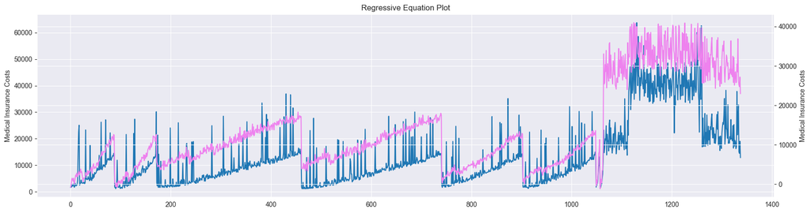

```python
# Add predictions to the dataframe
faminsure_combined['Prediction'] = predictions

plt.ylabel('Medical Insurance Costs')
primary_axes = faminsure_combined['medical_insurance_charges'].plot(label='Medical Insurance charges')
second_axes = primary_axes.twinx()
plt.ylabel('Medical Insurance Costs')
second_axes.plot(faminsure_combined['Prediction'], color='violet', label='Prediction')
plt.title('Regressive Equation Plot')

plt.show()
```

### You've made it to the end of this challenging case study — well done!

You've learnt to perform a number of things in Python that you weren't familiar with previously.

You've been able to:

Create Scatter Plots, Line Plots, Histograms, Bar Charts and Box Plots

Understand Descriptive Statistics from the .describe() functions

How to Detect and Remove Outliers from your Dataset

How to Subset and Filter your Dataframes

How to use Dual Axes to Plot Multiple Variables on different axes

How to interpret Correlation Coefficients and Heatmaps

How to convert Categorical Columns into Numerical Outputs

How to create and assess the goodness of fit for your Linear Regression Models

Well done! This is just the start of your foundation in Python as you grow more proficient in practicing against datasets both big and small.

Keep up the fantastic work and as always - if you have any questions, don't hesitate to reach out to the community, your mentor, or #slack channel for extra support! If you need, you can also reach out to the course creator, Chris Hui, via: chris.hui.sb.1990@gmail.com!

### Keep up the amazing work!